**Introduction**

This project explores the Nobel Prize dataset through the lens of data science. The Nobel Prize is not just a record of individual achievement—it reflects broader patterns of global leadership, academic focus, gender dynamics, and historical events. By analyzing this dataset, we can uncover trends that speak to the evolution of science, peace efforts, and cultural recognition over time.

**Why This Topic Matters**

This analysis is relevant both generally and within the field of data science. The Nobel Prize helps define who and what societies value. For data analysts, it offers a rich real-world dataset with imperfections, gaps, and structure—perfect for building practical skills in data wrangling, visualization, and storytelling.

**Project Goals**

Apply Python (Pandas, NumPy, Matplotlib) to explore and visualize real-world data.

Clean and prepare raw data to make it analysis-ready.

Develop insightful questions and answer them using clear, reproducible code.

Communicate findings through well-explained prose and graphics.

**Key Questions Explored**

Which countries have the most Nobel Prize winners?

How has gender distribution changed over time?

What categories are awarded most frequently?

What is the age distribution of winners?

How many prizes are awarded per year?

Which countries lead in female representation?

What is the average age at award by category?

By the end of this project, readers will have a clear understanding of how to structure a real-world data analysis task and communicate meaningful results.

We will first start by importing necessary libraries and reading our dataset

```python
import pandas as pd
import matplotlib.pyplot as plt
df = pd.read_csv('data.csv')
```

**Exploring, selecting, cleaning, and preparing the data:**

We will now do our exploration, cleaning and preparation of the dataset we just imported. Lets get started

we use .columns to get all the columns

```python
df.columns
```

```
Index(['id', 'firstname', 'surname', 'born', 'died', 'bornCountry',
       'bornCountryCode', 'bornCity', 'diedCountry', 'diedCountryCode',
       'diedCity', 'gender', 'year', 'category', 'overallMotivation', 'share',
       'motivation', 'name', 'city', 'country'],
      dtype='object')
```

Now we use .head() to find first 5 rows

```python
df.head()
```

|  | id | firstname | surname | born | died | bornCountry | bornCountryCode | bornCity | diedCountry | diedCountryCode | diedCity | gender | year | category | overallMotivation | share | motivation | name | city | country |
| --- | --- | --- | --- | --- | --- | --- | --- | --- | --- | --- | --- | --- | --- | --- | --- | --- | --- | --- | --- | --- |
| 0 | 1 | Wilhelm Conrad | Röntgen | 1845-03-27 | 1923-02-10 | Prussia (now Germany) | DE | Lennep (now Remscheid) | Germany | DE | Munich | male | 1901 | physics | NaN | 1 | "in recognition of the extraordinary services ... | Munich University | Munich | Germany |
| 1 | 2 | Hendrik A. | Lorentz | 1853-07-18 | 1928-02-04 | the Netherlands | NL | Arnhem | the Netherlands | NL | NaN | male | 1902 | physics | NaN | 2 | "in recognition of the extraordinary service t... | Leiden University | Leiden | the Netherlands |
| 2 | 3 | Pieter | Zeeman | 1865-05-25 | 1943-10-09 | the Netherlands | NL | Zonnemaire | the Netherlands | NL | Amsterdam | male | 1902 | physics | NaN | 2 | "in recognition of the extraordinary service t... | Amsterdam University | Amsterdam | the Netherlands |
| 3 | 4 | Henri | Becquerel | 1852-12-15 | 1908-08-25 | France | FR | Paris | France | FR | NaN | male | 1903 | physics | NaN | 2 | "in recognition of the extraordinary services ... | École Polytechnique | Paris | France |
| 4 | 5 | Pierre | Curie | 1859-05-15 | 1906-04-19 | France | FR | Paris | France | FR | Paris | male | 1903 | physics | NaN | 4 | "in recognition of the extraordinary services ... | École municipale de physique et de chimie indu... | Paris | France |

Similarly we use .tail() to find last 5 rows

```python
df.tail()
```

|  | id | firstname | surname | born | died | bornCountry | bornCountryCode | bornCity | diedCountry | diedCountryCode | diedCity | gender | year | category | overallMotivation | share | motivation | name | city | country |
| --- | --- | --- | --- | --- | --- | --- | --- | --- | --- | --- | --- | --- | --- | --- | --- | --- | --- | --- | --- | --- |
| 1007 | 1042 | Kang | Han | 1970-11-27 | 0000-00-00 | South Korea | KR | Gwangju | NaN | NaN | NaN | female | 2024 | literature | NaN | 1 | "for her intense poetic prose that confronts h... | NaN | NaN | NaN |
| 1008 | 1043 | Nihon Hidankyo | NaN | 1956-08-10 | 0000-00-00 | NaN | NaN | NaN | NaN | NaN | NaN | org | 2024 | peace | NaN | 1 | "for its efforts to achieve a world free of nu... | NaN | NaN | NaN |
| 1009 | 1044 | Daron | Acemoglu | 1967-09-03 | 0000-00-00 | Turkey | TR | Istanbul | NaN | NaN | NaN | male | 2024 | economics | NaN | 3 | "for studies of how institutions are formed an... | Massachusetts Institute of Technology (MIT) | Cambridge MA | USA |
| 1010 | 1045 | Simon | Johnson | 1963-00-00 | 0000-00-00 | United Kingdom | GB | Sheffield | NaN | NaN | NaN | male | 2024 | economics | NaN | 3 | "for studies of how institutions are formed an... | Massachusetts Institute of Technology (MIT) | Cambridge MA | USA |
| 1011 | 1046 | James | Robinson | 1960-00-00 | 0000-00-00 | NaN | NaN | NaN | NaN | NaN | NaN | male | 2024 | economics | NaN | 3 | "for studies of how institutions are formed an... | University of Chicago | Chicago IL | USA |

Now we use .shape function to find total rows and columns in our dataset

```python
df.shape
```

```
(1012, 20)
```

Now use .describe() which tells us about stats like mean, std, min, max etc

```python
df.describe()
```

|  | id | year | share |
| --- | --- | --- | --- |
| count | 1012.000000 | 1012.000000 | 1012.000000 |
| mean | 515.400198 | 1974.317194 | 2.031621 |
| std | 301.892463 | 34.747004 | 0.945073 |
| min | 1.000000 | 1901.000000 | 1.000000 |
| 25% | 253.750000 | 1950.000000 | 1.000000 |
| 50% | 507.500000 | 1980.000000 | 2.000000 |
| 75% | 773.250000 | 2004.000000 | 3.000000 |
| max | 1046.000000 | 2024.000000 | 4.000000 |

Now we use .info() to check count and data types of our columns

```python
df.info()
```

```
<class 'pandas.core.frame.DataFrame'>
RangeIndex: 1012 entries, 0 to 1011
Data columns (total 20 columns):
 #   Column             Non-Null Count  Dtype
---  ------             --------------  -----
 0   id                 1012 non-null   int64
 1   firstname          1012 non-null   object
 2   surname            979 non-null    object
 3   born               1011 non-null   object
 4   died               1012 non-null   object
 5   bornCountry        979 non-null    object
 6   bornCountryCode    979 non-null    object
 7   bornCity           977 non-null    object
 8   diedCountry        667 non-null    object
 9   diedCountryCode    667 non-null    object
 10  diedCity           661 non-null    object
 11  gender             1012 non-null   object
 12  year               1012 non-null   int64
 13  category           1012 non-null   object
 14  overallMotivation  23 non-null     object
 15  share              1012 non-null   int64
 16  motivation         1012 non-null   object
 17  name               746 non-null    object
 18  city               741 non-null    object
 19  country            743 non-null    object
dtypes: int64(3), object(17)
memory usage: 158.3+ KB
```

Now we start by checking if we find null values

```python
df.isnull().sum()
```

```
id                     0
firstname              0
surname               33
born                   1
died                   0
bornCountry           33
bornCountryCode       33
bornCity              35
diedCountry          345
diedCountryCode      345
diedCity             351
gender                 0
year                   0
category               0
overallMotivation    989
share                  0
motivation             0
name                 266
city                 271
country              269
dtype: int64
```

Here we see that we have alot of null values. But for our analysis we only care about certain columns like firstname, surname, born, year, category, gender and bornCountry. The rest of columns we can either simply drop them or ignore their null values because they are not needed for our analysis. We will drop a couple of unimportant columns and rest of unused columns can just stay ignored

```python
df.drop(['diedCountry', 'diedCity', 'overallMotivation'], axis=1, inplace=True)
#this code drops 3 columns 'diedCountry', 'diedCity', 'overallMotivation' which we dont need
```

We can confirm that our columns are dropped by .columns function

```python
df.columns
```

```
Index(['id', 'firstname', 'surname', 'born', 'died', 'bornCountry',
       'bornCountryCode', 'bornCity', 'diedCountryCode', 'gender', 'year',
       'category', 'share', 'motivation', 'name', 'city', 'country'],
      dtype='object')
```

Now whatever columns we require for our analysis, we will remove rows with missing values. Since there are very few missing values hence our analysis should still be accurate Now in the following code, we remove rows where bornCountry is missing. You might be surprised to see that just by doing this our count of missing surnames go from 33 to only 2 and this can be confirm by running the .isnull().sum() command again

```python
df.dropna(subset=['bornCountry'], inplace=True)
```

```python
df.isnull().sum()
```

```
id                   0
firstname            0
surname              2
born                 0
died                 0
bornCountry          0
bornCountryCode      0
bornCity             2
diedCountryCode    312
gender               0
year                 0
category             0
share                0
motivation           0
name               234
city               239
country            237
dtype: int64
```

We still have missing surnames so we remove those rows too

```python
df.dropna(subset=['surname'], inplace=True)
```

```python
df.isnull().sum()
```

```
id                   0
firstname            0
surname              0
born                 0
died                 0
bornCountry          0
bornCountryCode      0
bornCity             2
diedCountryCode    311
gender               0
year                 0
category             0
share                0
motivation           0
name               232
city               237
country            235
dtype: int64
```

Now we see that our required columns are cleaned and ready to use. Non required columns can simply be just ignored as they missing values but we dont need them

We also run a command to check if we have any duplicated

```python
df.duplicated().sum()
```

```
np.int64(0)
```

Thankfully we have no duplicates

Lets now check the data types of our columns

```python
df.dtypes
```

```
id                  int64
firstname          object
surname            object
born               object
died               object
bornCountry        object
bornCountryCode    object
bornCity           object
diedCountryCode    object
gender             object
year                int64
category           object
share               int64
motivation         object
name               object
city               object
country            object
dtype: object
```

Lets now use some creativity and add a new columns to get the age of scientists at the time or receiving award. We can create a new columns age_at_award for this

```python
# First convert 'born' to datetime if it's not already
df['born'] = pd.to_datetime(df['born'], errors='coerce')

# Now create a new 'age_at_award' column
df['age_at_award'] = df['year'] - df['born'].dt.year
```

We have done all the necessary exploration, cleaning and checking required for our analysis.

**Data Analysis Tasks**

Lets get started with our analysis

**1)Top 10 Countries by Nobel Prize Winners**

```python
top_countries = df['bornCountry'].value_counts().head(10)
top_countries
```

```
bornCountry
USA                297
United Kingdom      93
Germany             67
France              58
Sweden              30
Japan               28
Canada              21
the Netherlands     19
Switzerland         19
Russia              18
Name: count, dtype: int64
```

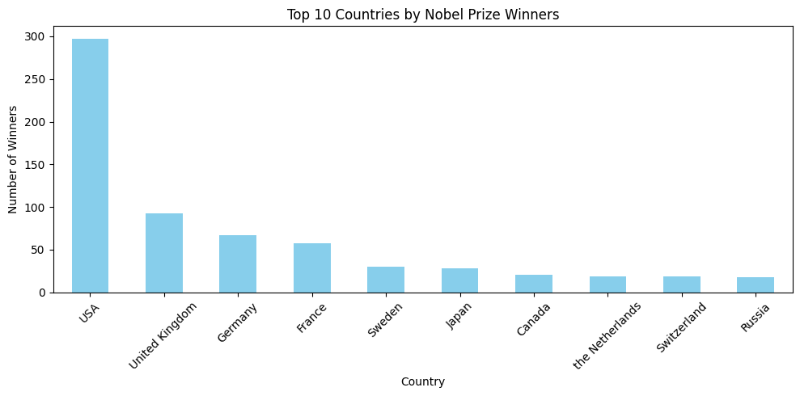

```python
top_countries.plot(kind='bar', figsize=(10,5), color='skyblue')
plt.title('Top 10 Countries by Nobel Prize Winners')
plt.xlabel('Country')
plt.ylabel('Number of Winners')
plt.xticks(rotation=45)
plt.tight_layout()
plt.show()
```

Our analysis shows that the United States dominates with nearly 300 Nobel Prize winners, far outpacing all other countries. The United Kingdom and Germany follow, but with significantly fewer recipients. This suggests a strong historical concentration of Nobel achievements in Western countries, particularly the U.S.

**2)How has the gender distribution of Nobel Prize winners changed over time?**

```python
gender_trend = df.groupby(['year', 'gender']).size().unstack()
gender_trend.tail()
```

| gender year | female | male | org |
| --- | --- | --- | --- |
| 2020 | 4.0 | 7.0 | 1.0 |
| 2021 | 1.0 | 12.0 | NaN |
| 2022 | 2.0 | 10.0 | 2.0 |
| 2023 | 4.0 | 7.0 | NaN |
| 2024 | 1.0 | 10.0 | 1.0 |

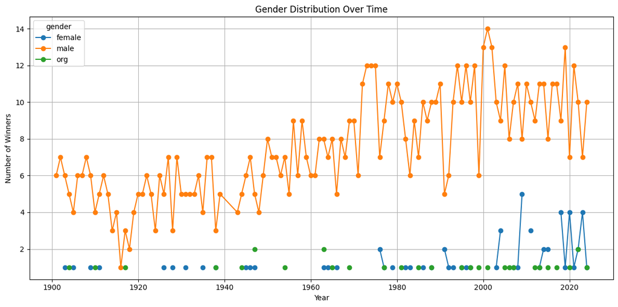

```python
gender_trend.plot(kind='line', figsize=(12,6), marker='o')
plt.title('Gender Distribution Over Time')
plt.xlabel('Year')
plt.ylabel('Number of Winners')
plt.grid(True)
plt.tight_layout()
plt.show()
```

Our graph show that Male laureates consistently outnumber female and organizational recipients throughout the timeline. However, starting in the 2000s, there's a noticeable rise in female winners, reflecting slow but steady progress toward gender representation in Nobel recognitions.

**3)Which categories are awarded most frequently over time?**

```python
category_trend = df.groupby(['year', 'category']).size().unstack().fillna(0)
category_trend.tail()
```

| category year | chemistry | economics | literature | medicine | peace | physics |
| --- | --- | --- | --- | --- | --- | --- |
| 2020 | 2.0 | 2.0 | 1.0 | 3.0 | 1.0 | 3.0 |
| 2021 | 2.0 | 3.0 | 1.0 | 2.0 | 2.0 | 3.0 |
| 2022 | 3.0 | 3.0 | 1.0 | 1.0 | 3.0 | 3.0 |
| 2023 | 3.0 | 1.0 | 1.0 | 2.0 | 1.0 | 3.0 |
| 2024 | 3.0 | 3.0 | 1.0 | 2.0 | 1.0 | 2.0 |

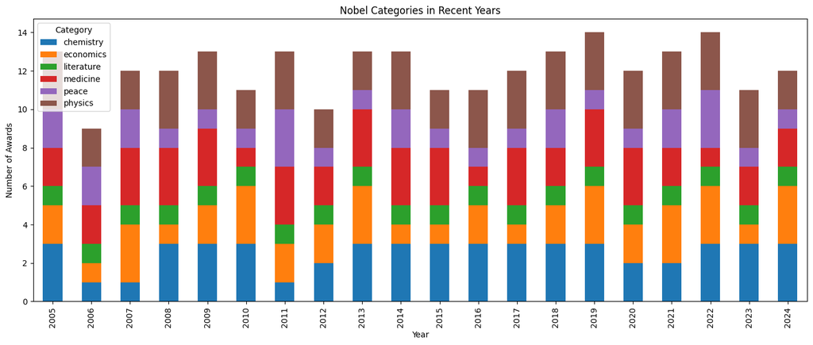

```python
category_trend.tail(20).plot(kind='bar', stacked=True, figsize=(14,6))
plt.title('Nobel Categories in Recent Years')
plt.xlabel('Year')
plt.ylabel('Number of Awards')
plt.legend(title='Category')
plt.tight_layout()
plt.show()
```

we see that from 2005 to 2024, the most consistently awarded categories are Physics, Medicine, and Chemistry. Economics and Peace also show strong presence, while Literature tends to have the fewest awards annually. The overall distribution remains balanced, suggesting stable recognition across scientific and humanitarian fields.

**4)What is the age distributions Nobel Prize winners?**

```python
df['age_at_award'] = df['year'] - pd.to_datetime(df['born'], errors='coerce').dt.year
df['age_at_award']
```

```
0       56.0
1       49.0
2       37.0
3       51.0
4       44.0
        ...
1007    54.0
1008    68.0
1009    57.0
1010     NaN
1011     NaN
Name: age_at_award, Length: 1012, dtype: float64
```

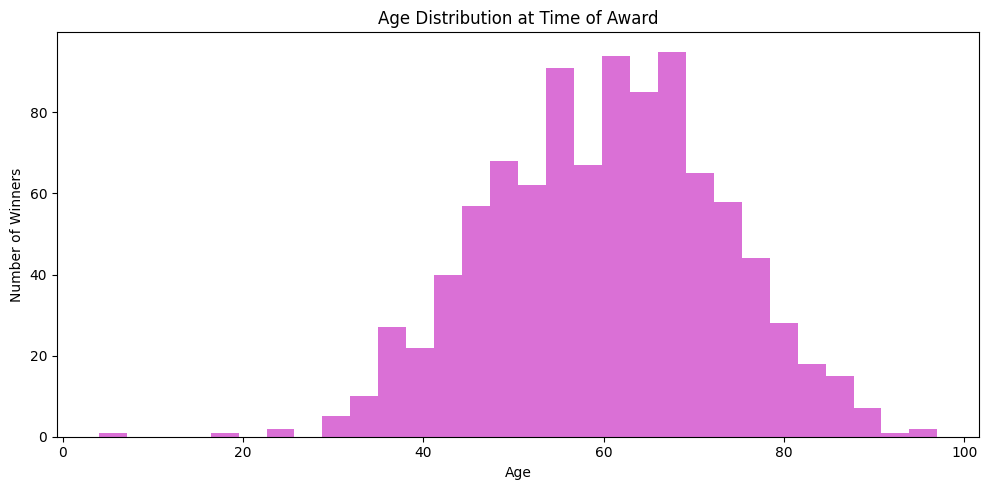

```python
df['age_at_award'].dropna().plot(kind='hist', bins=30, figsize=(10,5), color='orchid')
plt.title('Age Distribution at Time of Award')
plt.xlabel('Age')
plt.ylabel('Number of Winners')
plt.tight_layout()
plt.show()
```

Most Nobel Prize winners receive the award between the ages of 55 and 70, with the peak around 60. Very few recipients are under 40, indicating that Nobel recognition often comes after long-term contributions and career maturity.

**5)How many Nobel Prizes were awarded each year?**

```python
prizes_per_year = df['year'].value_counts().sort_index()
prizes_per_year
```

```
year
1901     6
1902     7
1903     7
1904     6
1905     5
        ..
2020    12
2021    13
2022    14
2023    11
2024    12
Name: count, Length: 121, dtype: int64
```

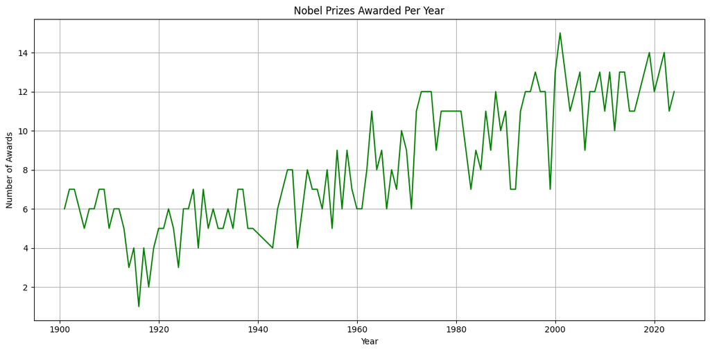

```python
prizes_per_year.plot(kind='line', figsize=(12,6), color='green')
plt.title('Nobel Prizes Awarded Per Year')
plt.xlabel('Year')
plt.ylabel('Number of Awards')
plt.grid(True)
plt.tight_layout()
plt.show()
```

This line graph shows a steady rise in the number of Nobel Prizes awarded annually over the past century. Noticeable drops around the World Wars suggest global disruptions, but from the 1970s onward, the number of awards remains consistently high, reflecting expanded categories and increased global recognition.

**6)Which countries have the most female Nobel Prize winners?**

```python
female_top = df[df['gender'] == 'female']['bornCountry'].value_counts().head(10)
female_top
```

```
bornCountry
USA                            17
France                          6
Italy                           2
Russian Empire (now Poland)     2
Liberia                         2
Iran                            2
Germany                         2
Northern Ireland                2
Sweden                          2
Canada                          2
Name: count, dtype: int64
```

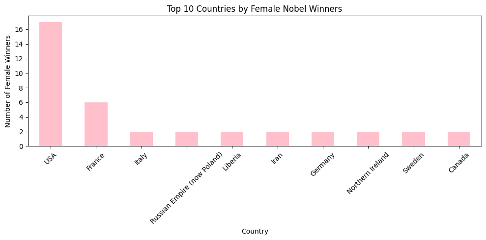

```python
female_top.plot(kind='bar', figsize=(10,5), color='pink')
plt.title('Top 10 Countries by Female Nobel Winners')
plt.xlabel('Country')
plt.ylabel('Number of Female Winners')
plt.xticks(rotation=45)
plt.tight_layout()
plt.show()
```

The United States leads significantly in female Nobel Prize recipients, followed by France. Other countries like Italy, Germany, and Sweden show much smaller counts, highlighting a global gender gap and the dominance of a few countries in advancing female achievement.

**7)Average Age at Award by Nobel Prize Category**

```python
avg_age_by_category = df.groupby('category')['age_at_award'].mean().sort_values()
avg_age_by_category
```

```
category
physics       57.522124
medicine      58.716814
chemistry     58.810526
peace         60.070796
literature    64.833333
economics     66.877778
Name: age_at_award, dtype: float64
```

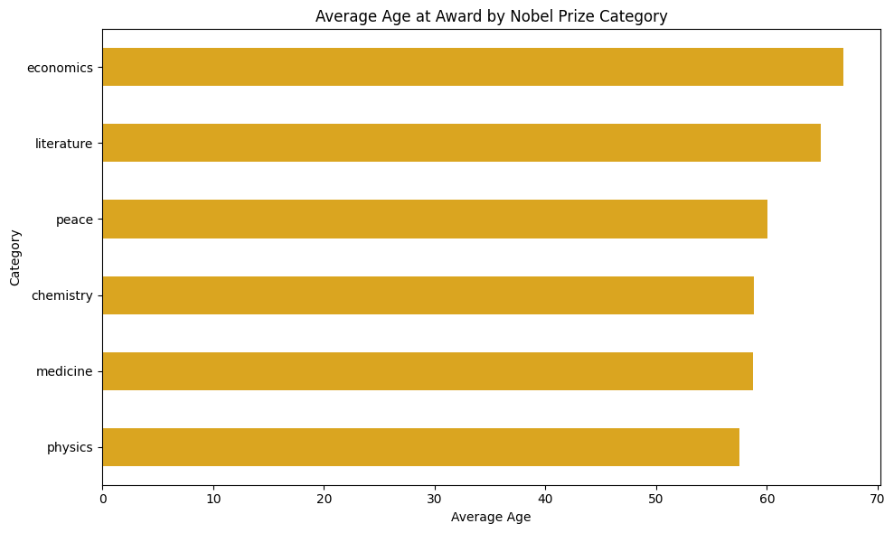

```python
avg_age_by_category.plot(kind='barh', figsize=(10,6), color='goldenrod')
plt.title('Average Age at Award by Nobel Prize Category')
plt.xlabel('Average Age')
plt.ylabel('Category')
plt.tight_layout()
plt.show()
```

The average age at which Nobel Prizes are awarded varies slightly across categories. Winners in Economics and Literature tend to receive the prize later in life (around 66 years), while those in Physics, Medicine, and Chemistry typically receive it slightly earlier (around 58–60 years). This reflects how theoretical or policy-based contributions often require more time to gain recognition.

**Conclusion**

This project demonstrated the full workflow of a real-world data analysis task using the Nobel Prize winners dataset. We loaded the data, examined its structure, and cleaned it to ensure quality. From there, we asked relevant questions, wrote targeted queries, and visualized our results clearly and effectively.

Through this process, we practiced essential data analysis skills: working with imperfect data, building insights through code, and communicating findings visually. This experience prepares us well for future projects and provides a strong foundation for tackling real-world data problems with confidence.